# Data Package Checks Report

This report was created on 2024-06-13 by Bibi Powers-McCormack.

## Summary

**Kassianov_2023_AML_Plumes_Manuscript_Data_Package**

## Required Checks

### Required Checks

The following checks are required to pass before a data package will be published.  
- **FOLDER** `no_special_chrs`: The only characters allowed in folder names are lowercase letters, uppercase letters, numbers, underscores, periods, and hyphens.  
- **FILE** `no_special_chrs`: The only characters allowed in file names are lowercase letters, uppercase letters, numbers, underscores, periods, and hyphens.

### Special Chrs

#### File Names

> **FAILED**

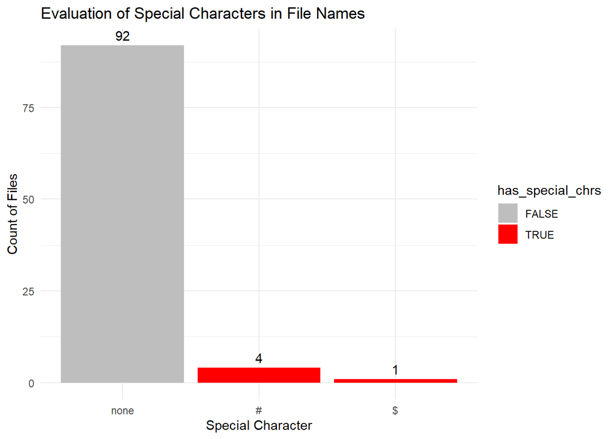

| special_chrs | special_chrs_count | files |
| --- | --- | --- |
| # | 4 | ESSDIVE_Metadata_Template_#4_ek_01-26_.docx, example_flmd_#1_ek_01-26_.xlsx, readme_template_#3_ek_01-26_.docx, template_dd_#2_ek_01-10_.xlsx |
| $ | 1 | Documents$ssianov_2023_AML_Plumes_ESS-DIVE_metadata.docx |

#### Folder Names

> **PASSED**

## Recommended Checks

### Recommended Checks

The following checks are recommended to pass before a data package will be published.  
- **FILE** `no_proprietary_exts`: Proprietary files are strongly discouraged.  
- **TABULAR DATA HEADERS** `no_special_chrs`: The only characters recommended in tabular data header names are lowercase letters, uppercase letters, numbers, underscores, periods, and hyphens.

### File Extensions

> **FAILED**

> `8` of `97` file(s) in your data package are proprietary. Proprietary files are strongly discouraged and, if present, are highlighted in red below. Please replace these files with a non-proprietary file type or discuss alternative options with the Data Management Team.

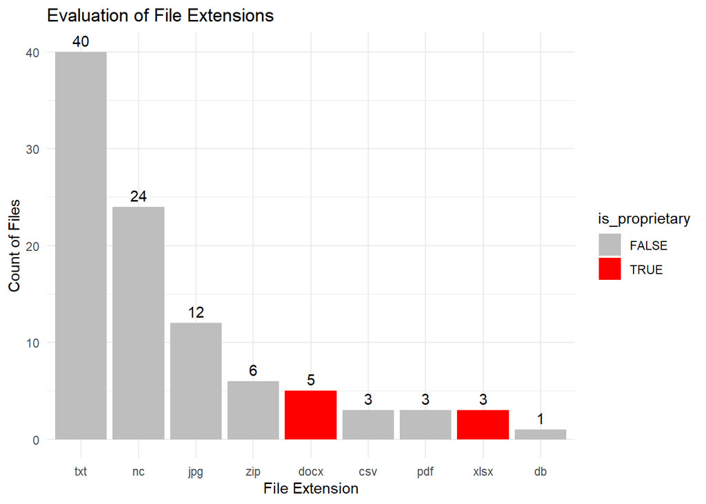

[output not shown]

## About Your Data

### Directory Tree

Below is a list of all of your folders and files that were present when the report was generated.

```
## Z:/00_Cross-SFA_ESSDIVE-Data-Package-Upload/03_Manuscript-Data-Package-Folders/00_ARCHIVE-WHEN-PUBLISHED/Kassianov_2023_AML_Plumes_Manuscript_Data_Package/
## ├── Archive
## │   ├── aeronet.gsfc.nasa.gov_new_web_units_accessed_2024-03-06.pdf
## │   ├── AML_LAS__size_distribution__September12smoke_September20background_2020.xlsx
## │   ├── Readme_v01_.pdf
## │   ├── work_c_all_
## │   │   ├── ESSDIVE_Metadata_Template_#4_ek_01-26_.docx
## │   │   ├── example_flmd_#1_ek_01-26_.xlsx
## │   │   ├── readme_template_#3_ek_01-26_.docx
## │   │   └── template_dd_#2_ek_01-10_.xlsx
## │   └── work_c_all_.zip
## ├── Kassianov_2023_AML_Plumes
## │   ├── AML_Ceilometer_
## │   │   ├── rldceilC1.b1.20200909.080010.nc
## │   │   ├── rldceilC1.b1.20200910.080002.nc
## │   │   ├── rldceilC1.b1.20200911.154142.nc
## │   │   ├── rldceilC1.b1.20200912.080015.nc
## │   │   ├── rldceilC1.b1.20200913.080007.nc
## │   │   ├── rldceilC1.b1.20200914.080016.nc
## │   │   ├── rldceilC1.b1.20200915.080008.nc
## │   │   ├── rldceilC1.b1.20200916.080000.nc
## │   │   ├── rldceilC1.b1.20200917.080008.nc
## │   │   ├── rldceilC1.b1.20200918.080000.nc
## │   │   ├── rldceilC1.b1.20200919.080008.nc
## │   │   └── rldceilC1.b1.20200920.080000.nc
## │   ├── AML_Ceilometer_.zip
## │   ├── AML_CSPHOT_
## │   │   ├── CSPHOT_20200901_20200930_.txt
## │   │   └── CSPHOT_20200901_20200930_DailyAverages_.txt
## │   ├── AML_CSPHOT_.zip
## │   ├── AML_LAS__size_distribution__September12smoke_September20background_2020.csv
## │   ├── AML_MFRSR_irradiances_
## │   │   ├── diffuse_20200909.txt
## │   │   ├── diffuse_20200910.txt
## │   │   ├── diffuse_20200911.txt
## │   │   ├── diffuse_20200912.txt
## │   │   ├── diffuse_20200913.txt
## │   │   ├── diffuse_20200914.txt
## │   │   ├── diffuse_20200915.txt
## │   │   ├── diffuse_20200916.txt
```

[output cut: 51 more lines]

```
## │   │   ├── rldtsiskyimageC1.a1.20200916.201200.jpg
## │   │   ├── rldtsiskyimageC1.a1.20200917.201200.jpg
## │   │   ├── rldtsiskyimageC1.a1.20200918.201200.jpg
## │   │   ├── rldtsiskyimageC1.a1.20200919.201200.jpg
## │   │   ├── rldtsiskyimageC1.a1.20200920.201200.jpg
## │   │   └── Thumbs.db
## │   ├── AML_TSI_images_.zip
## │   ├── EMSL_miniSPLAT__mass_spectrum__September_11_2020.txt
## │   ├── EMSL_SMPS__size_distribution__September_11_2020.txt
## │   ├── Kassianov_2024_AML_Plumes_dd.csv
## │   ├── Kassianov_2024_AML_Plumes_flmd.csv
## │   └── readme_Kassianov_2024_AML_Plumes.pdf
## ├── Kassianov_2024_AML_Plumes_ESS-DIVE_metadata.docx
## ├── readme_Kassianov_2024_AML_Plumes.docx
## └── ~$ssianov_2023_AML_Plumes_ESS-DIVE_metadata.docx
```